# US Consumer complaints analysis

#### Introduction

This dataset was part of a project on US consumer complaints to finanaical intistituions the brief given was to look at the dataset, porcess it for anlysis and and use multiple types of analysis methods to find patterns in the data and show insights in the current trends in this field.

This is a beta publication of the report as of April 2020 and the main report will be published in summer 2020.

#### Dataset and Cleaning

The dataset is composed of data on complaints to financial comapnies with issues regarding financial products

There are:

- 939 companies
- 148 unique issues with many more sub issues categories
- 17 unique products with many more sub product categories

Since the data frame contains mostly nominal data we will need to transform cetain variables using [interger and one-hot encoding](https://machinelearningmastery.com/how-to-one-hot-encode-sequence-data-in-python/) to prepare the data for machined learning techniques.

Since there are many Issues and Companies [factor analysis](https://www.datacamp.com/community/tutorials/introduction-factor-analysis) might be needed to reduce the numbers of levels in these two factors

```r
#Loading dependencies
        suppressMessages(library(tidyverse))
        suppressMessages(library(magrittr))
        suppressMessages(library(viridis))
        suppressMessages(library(RColorBrewer))
        suppressMessages(library(forcats))
        suppressMessages(library(gridExtra))
        suppressMessages(library(rgeos))
        suppressMessages(library(rgdal))
        suppressMessages(library(kableExtra))
        suppressMessages(library(reticulate))
        suppressMessages(library(htmltab))
        suppressMessages(library(leaflet))
```

```r
#Load the data
        Complaints <- read_csv("sample.csv")

        #Drop first four columns
        Complaints <- Complaints[,5:22]

        #Converting nominal variables in dataframe to factors
        Complaints[,c(2:5,7:13,15:17)] %<>%  lapply(as.factor)

        #Convert date columns
        Complaints[,c(1,14)] %<>% lapply(as.Date)
```

```r
#Add month column
        Complaints %<>% mutate(month=months.POSIXt(Complaints$`Date sent to company`))
        Complaints$month <- as.factor(Complaints$month)

        #Order factors
        Complaints$month<-ordered(Complaints$month, levels = c("January", "February", "March", "April", "May", "June", "July", "August", "September", "October", "November", "December"))

        levels(Complaints$Product)<-c("Bank account", "Bank account", "Loan", "Card", "Card", "Credit reporting", "Credit reporting", "Debt collection", "Money transfer", "Money transfer", "Mortgage", "Other", "Loan", "Loan", "Card", "Loan", "Loan")

        #Kable and Kable styling applies twitters bootstrap stylying to html
        kable(head(Complaints[,-6])) %>%
            kable_styling(c("responsive","bordered"), font_size = 10) %>%
            scroll_box(width = "100%")
```

| Date received | Product | Sub-product | Issue | Sub-issue | Company public response | Company | State | ZIP code | Tags | Consumer consent provided? | Submitted via | Date sent to company | Company response to consumer | Timely response? | Consumer disputed? | Complaint ID | month |
| --- | --- | --- | --- | --- | --- | --- | --- | --- | --- | --- | --- | --- | --- | --- | --- | --- | --- |
| 2017-01-30 | Bank account | Checking account | Problems caused by my funds being low | NA | NA | JPMORGAN CHASE & CO. | IL | 60619 | NA | NA | Referral | 2017-02-02 | Closed with monetary relief | Yes | No | 2318415 | February |
| 2019-05-29 | Loan | Installment loan | Incorrect information on your report | Account information incorrect | NA | ONEMAIN FINANCIAL HOLDINGS, LLC. | MN | 553XX | NA | Consent provided | Web | 2019-05-29 | Closed with explanation | Yes | NA | 3257509 | May |
| 2018-06-10 | Loan | Loan | Managing the loan or lease | Problem with the interest rate | NA | Skopos Financial, LLC | FL | 328XX | NA | Consent provided | Web | 2018-06-10 | Closed with explanation | Yes | NA | 2931620 | June |
| 2018-10-13 | Credit reporting | Credit reporting | Incorrect information on your report | Information belongs to someone else | NA | CAPITAL ONE FINANCIAL CORPORATION | VA | 238XX | NA | Consent not provided | Web | 2018-10-13 | Closed with explanation | Yes | NA | 3045441 | October |
| 2015-02-25 | Mortgage | Conventional fixed mortgage | Loan servicing, payments, escrow account | NA | NA | PNC Bank N.A. | FL | 34986 | NA | NA | Web | 2015-02-25 | Closed | Yes | No | 1256612 | February |
| 2014-03-07 | Debt collection | Payday loan | Taking/threatening an illegal action | Threatened to sue on too old debt | NA | 4 Star Resolution LLC (Closed) | OR | 97045 | NA | NA | Web | 2014-04-24 | Untimely response | No | No | 750097 | April |

## Analysis

### Closed with monetary relief analysis

Are some products more likely to be “Closed with monetary relief” than others?

Looking at the below plot card and bank account products have the highest count of complaints unsurprising as they would have one of the largest user bases.

[figure not shown]

```r
#Group by monetary relief
        Monetary_relief <-  Complaints %>% select(1:9,-6,-7,15) %>%
                            filter(Complaints$`Company response to consumer` == 'Closed with monetary relief')

        Response_by_prod    <- Monetary_relief$Product  %>% fct_count(sort = T,)  %>% top_n(5)
        Response_by_state   <- Monetary_relief$State    %>% fct_count(sort = T,)  %>% top_n(5)
        Response_by_company <- Monetary_relief$Company  %>% fct_count(sort = T,)  %>% top_n(5)

        Monetary_relief <- bind_cols(Response_by_company[1:5,],Response_by_state[1:5,],Response_by_prod[1:5,])
        Monetary_relief %<>%  rename(Company = f,
                                    State=f1,
                                    Product=f2,
                                    )
        #rm dendundent varibales from global env
        #rm(Response_by_company,Response_by_prod,Response_by_state)

        p1 <- Monetary_relief %>%  ggplot(aes(x= Company,y=n))+
            geom_col(fill = "#03396c") + coord_flip() +
            labs(title = 'Number of closed with monetary relief complaints by Company',
                subtitle = 'Top 6 Companies')

        p2 <- Monetary_relief %>%  ggplot(aes(x=State,y=n1)) +
            geom_col(fill = "#03396c") + coord_flip() +
            labs(title = 'Number of closed with monetary relief complaints by State',
                subtitle = 'Top 6 States')

        p3 <- Monetary_relief %>%  ggplot(aes(x=Product,y= n2, ))+
            geom_col(fill = "#03396c") + coord_flip() +
            labs(title = 'Number of closed with monetary relief complaints by Product',
                subtitle = 'Top 6 Products')


        grid.arrange(p1, p2, p3, nrow=3)
```

### By Company Stats

Equifax, Transunion holdings annd Experian all have much higher companints than the others. They are conusmer credit reporters tracking everyone credit scores. The Equifax wiki has a whole section for [“Lawsuits and fines”](https://www.cnbc.com/2019/07/22/equifax-to-pay-up-to-650-million-in-data-breach-settlement.html) that show all three have been in multiple scandals in 2000, 2013, 2014, 2017 and 2019.

The next four are the biggest banks in america

The main trend I can see is unsurprisingly the bigger the customer base of the comapny the more complaints it accumulates

We should find some way to weight each company by how large there customer base is so we can get a “per capita” type measuerment of complaints

```r
#Group by and show summary
        Company_Complaints <- group_by(Complaints,Company) %>% summarise(n=n()) %>% arrange(desc(n))

        #Kable and Kable styling applies twitters bootstrap stylying to html
        Company_Complaints %>%  top_n(10) %>% kable() %>% kable_styling()
```

| Company | n |
| --- | --- |
| EQUIFAX, INC. | 964 |
| TRANSUNION INTERMEDIATE HOLDINGS, INC. | 908 |
| Experian Information Solutions Inc. | 888 |
| BANK OF AMERICA, NATIONAL ASSOCIATION | 578 |
| WELLS FARGO & COMPANY | 503 |
| JPMORGAN CHASE & CO. | 455 |
| CITIBANK, N.A. | 370 |
| CAPITAL ONE FINANCIAL CORPORATION | 258 |
| Ocwen Financial Corporation | 213 |
| Navient Solutions, LLC. | 211 |

The distribution of the number of complaints companies recieved over the total period

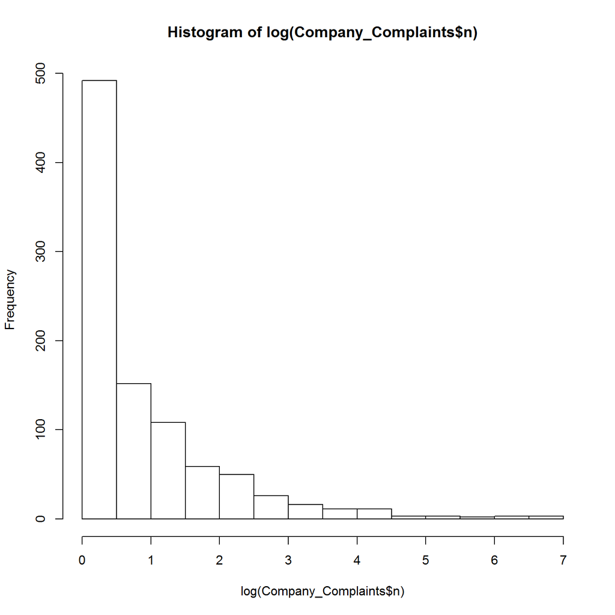

```r
hist(log(Company_Complaints$n))
```

The mean number of complaints companies recieved

```r
mean(Company_Complaints$n)
```

```
## [1] 10.64963
```

### By state

Here we can see the more populous state have the most complaints. To alleviate this we can use population proportions to weight each state and then get a number of complaints per capita variable.

Using html.tab() we can go to the wikipedia page for US states and parse the information we need.

The tags column has a lot of NA and is probably not used oftern in the complaints process

The proportions of product, company response and tags remain consistent across state indicating that the system of financial institutions operates on a national level not a regional or local state level.

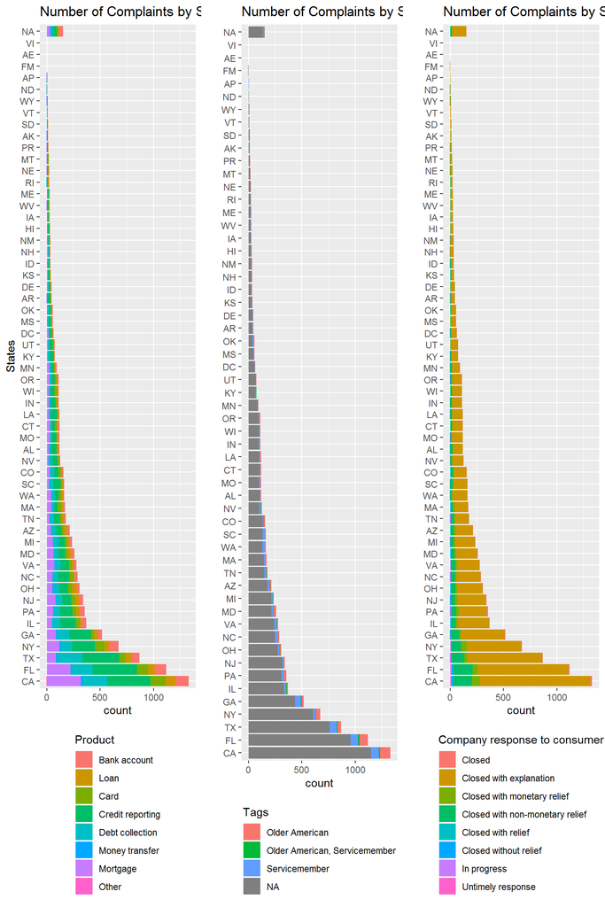

```r
#Plot the data
        Complaints %>%  ggplot(aes(fct_infreq(State), fill=Product)) + geom_bar() +     coord_flip() + xlab("States") + theme(legend.position = "bottom", legend.direction = "vertical")+ labs(title = 'Number of Complaints by State and Product') -> p1

        Complaints %>%  ggplot(aes(fct_infreq(State), fill=Tags)) + geom_bar() + coord_flip() + xlab('') + theme(legend.position = "bottom", legend.direction = "vertical")+ labs(title = 'Number of Complaints by State and Tag') -> p2

        Complaints %>%  ggplot(aes(fct_infreq(State), fill=`Company response to consumer`)) + geom_bar() + coord_flip() + xlab('') + theme(legend.position = "bottom", legend.direction = "vertical") + labs(title = 'Number of Complaints by State and Company Response')-> p3

        grid.arrange(p1, p2, p3, nrow=1)
```

#### HTML tab and per capita weighting

Using HTMLtab package, x-paths and wikiepedia we can downloand the population statistics for each state in the US and use that to weight the complaint conut per state to get a per capita measurement

Also a proportional analysis of the complaint conut per state vs. population proportions by state may be appropriate

```r
# Create url object
        States_wiki <- "https://en.wikipedia.org/wiki/List_of_states_and_territories_of_the_United_States_by_population"

        # Xpath file gooten from inpsect html
        State_pop <- htmltab(States_wiki, which ="//*[@id='mw-content-text']/div/table[1]")

        #Format the data frame
        State_pop <- State_pop[1:50,c(3,4,12)]
        #Turn percentages into decimal float
        State_pop[,3] <- as.numeric(sub("%","",State_pop[,3]))/100
        #Turn pop number into a decimal percetange
        State_pop[,2] <- as.numeric(gsub(",", "", State_pop[,2]))
        #Add Complaints buy State counts
        State_Complaints <-  group_by(Complaints,State) %>%
                            summarise(n=n()) %>% arrange(desc(n)) %>% na.omit()

        #Column state was manually abbreviated and exported
        #write.csv(State_pop,'State_pop.csv')
        State_pop_m <- read_csv("State_pop.csv")
        State_pop[,1] <- State_pop_m[,2]

        #Test if Complaints states and staes from wikipeadia match
        State_pop$State %<>% as.factor()
        testA <- levels(State_pop$State)
        testB <- levels(Complaints$State)
        #Missing 7 tiny regions including micronesia other wise fine
        rm(testA,testB)

        #Format for left join
        State_pop$State <- as.character(State_pop$State)
        Complaints$State <- as.character(Complaints$State)
```

Here we created a table of states with population and complaints statistics

```r
#Left join and create new column
        State_Complaints <- left_join(State_pop,State_Complaints)

        State_Complaints %<>%  mutate(N_Complaints_per_million_citizens =
                                        (n / `Census population >> Estimate, July 1, 2019`)*1000000)

        State_Complaints[,5] <- round(State_Complaints[,5],digits=2)

        State_Complaints %<>% arrange(desc(N_Complaints_per_million_citizens))

        #Display table
        kable(head(State_Complaints)) %>%
            kable_styling(c("responsive","bordered"), font_size = 10) %>%
            scroll_box(width = "100%")
```

| State | Census population >> Estimate, July 1, 2019 | Percent of the total U.S. population, 2019 | n | N_Complaints_per_million_citizens |
| --- | --- | --- | --- | --- |
| DC | 731545 | 0.0022 | 64 | 87.49 |
| FL | 21477737 | 0.0647 | 1118 | 52.05 |
| GA | 10617423 | 0.0320 | 519 | 48.88 |
| MD | 6045680 | 0.0182 | 259 | 42.84 |
| DE | 1059361 | 0.0032 | 45 | 42.48 |
| NV | 3155070 | 0.0095 | 128 | 40.57 |

#### Plot

Here we can see that Washington DC, Florida and Georgia are have disproportionate numbers of complaints by their citzens relate to their population size.

[figure not shown]

```r
#Plot complaints per capita over state
        State_Complaints %>% ggplot(aes(y= N_Complaints_per_million_citizens,
                                        x = reorder(State,X = N_Complaints_per_million_citizens,
                                        fill = "#03396c"))) +
                                    geom_col() + coord_flip() +
                                    ylab("Number of complaints per one million citizens") +
                                    xlab("States")
```

### Geo Analysis

A map is being prepared to show the geographic distribution of the data

```r
bou <- readOGR(dsn= paste0( ".\\USA_States"),
                    layer="USA_States",
                    verbose=FALSE)

        States <- table(Complaints$State)

        bou@data$STATE_ABBR<-as.vector(bou@data$STATE_ABBR)

        bou@data<-transform.data.frame(bou@data,complaints=ifelse(STATE_ABBR %in% names(States),States[STATE_ABBR], NA))

        mybins <- c(0,500,1000,2000,3000,4000,5000,7500,10000,12500,15000,17500)

        mypalette <- colorBin( palette="viridis", domain=bou@data$complaints, na.color="grey", bins=mybins)

        mytext <- paste("State: ", bou@data$STATE_ABBR,"<br/>",
                        "Complaints: ", bou@data$complaints,"<br/>",
                        sep="") %>% lapply(htmltools::HTML)

        map <-  leaflet(bou) %>%
                addTiles()  %>%
                setView(lat=53, lng=-110 , zoom=3) %>%
                addPolygons(
                            fillColor = ~ mypalette(complaints),
                            stroke=TRUE,
                            fillOpacity = 0.9,
                            color="white",
                            weight=0.3,
                            label = mytext,
                            labelOptions = labelOptions(
                            style = list("font-weight" = "normal",
                                        padding = "3px 8px"),
                            textsize = "13px",
                            direction = "auto"
                            )
                ) %>%

        addLegend(pal=mypalette, values=~complaints,
                opacity=0.9, title = "Number of complaints",
                position = "bottomleft" )
```

```r
States<-table(Complaints$State)

        StateReliefTotal<-c()

        for(i in 1:length(States))
        {
        StateReliefTotal<-c(StateReliefTotal, sum(Complaints$State==names(States)[i] & Complaints$`Company response to consumer`=="Closed with monetary relief"))
        }

        StateReliefProportion<-StateReliefTotal/States

        StateReliefProportion<-StateReliefProportion*100
        bou@data$STATE_ABBR<-as.vector(bou@data$STATE_ABBR)

        bou@data<-transform.data.frame(bou@data,percentage=ifelse(STATE_ABBR %in% names(States),StateReliefProportion[STATE_ABBR], NA))

        mybins <- c(0.5,1,1.5,2,2.5,3,3.5,4,4.5,5,5.5,6,6.5,7,7.5,8,8.5)

        mypalette <- colorBin( palette="viridis", domain=bou@data$percentage, na.color="grey", bins=mybins)

        mytext <- paste("State: ", bou@data$STATE_ABBR,"<br/>",
                        "Percentage: ", bou@data$percentage,"<br/>",
                        sep="") %>% lapply(htmltools::HTML)

        map<-leaflet(bou) %>%
        addTiles()  %>%
        setView( lat=53, lng=-120 , zoom=3) %>%
        addPolygons(
            fillColor = ~mypalette(percentage),
            stroke=TRUE,
            fillOpacity = 0.9,
            color="white",
            weight=0.3,
            label = mytext,
            labelOptions = labelOptions(
            style = list("font-weight" = "normal", padding = "3px 8px"),
            textsize = "13px",
            direction = "auto"
            )
        ) %>%
        addLegend( pal=mypalette, values=~percentage, opacity=0.9, title = "Percentage of cases closed with monetary relief", position = "bottomleft" )

        map
```

[interactive chart not shown]

### Time series analysis

Time analysis wile be done to see if there are any trends over the years.

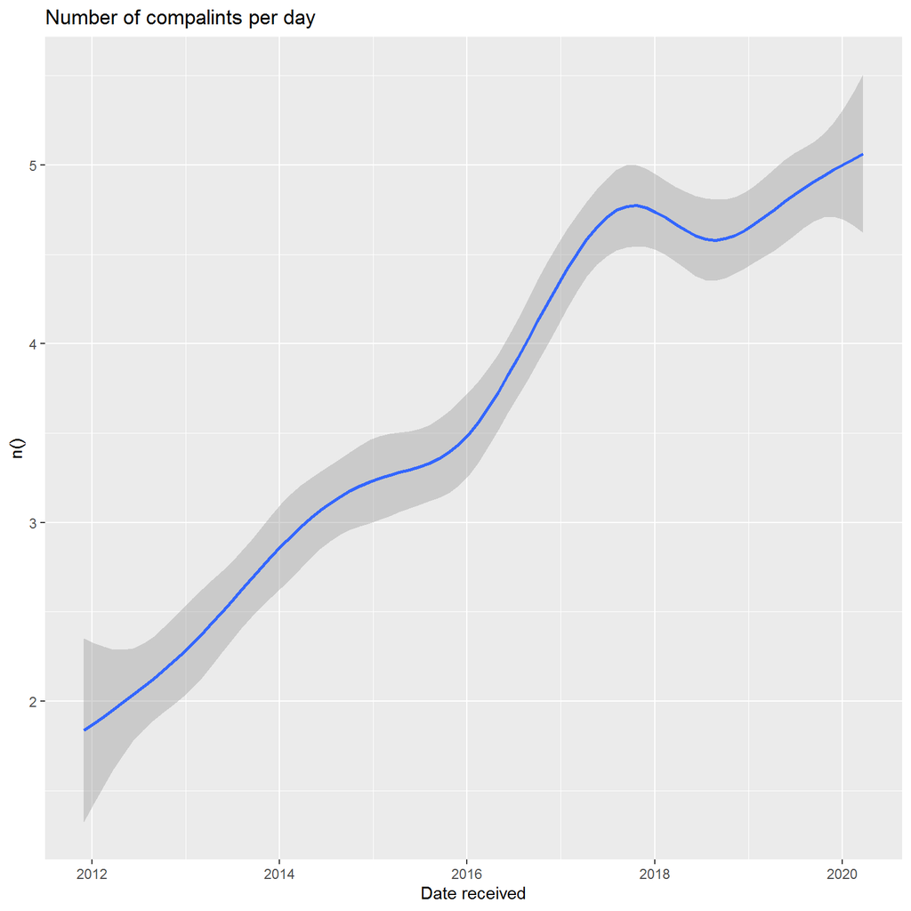

```r
Complaints %>%  group_by(`Date received`) %>% summarise(n()) %>%
                        ggplot(aes(x = `Date received`, y = `n()`)) +
                        labs(title = "Number of compalints per day")-> p1

        p1 + geom_smooth()
```

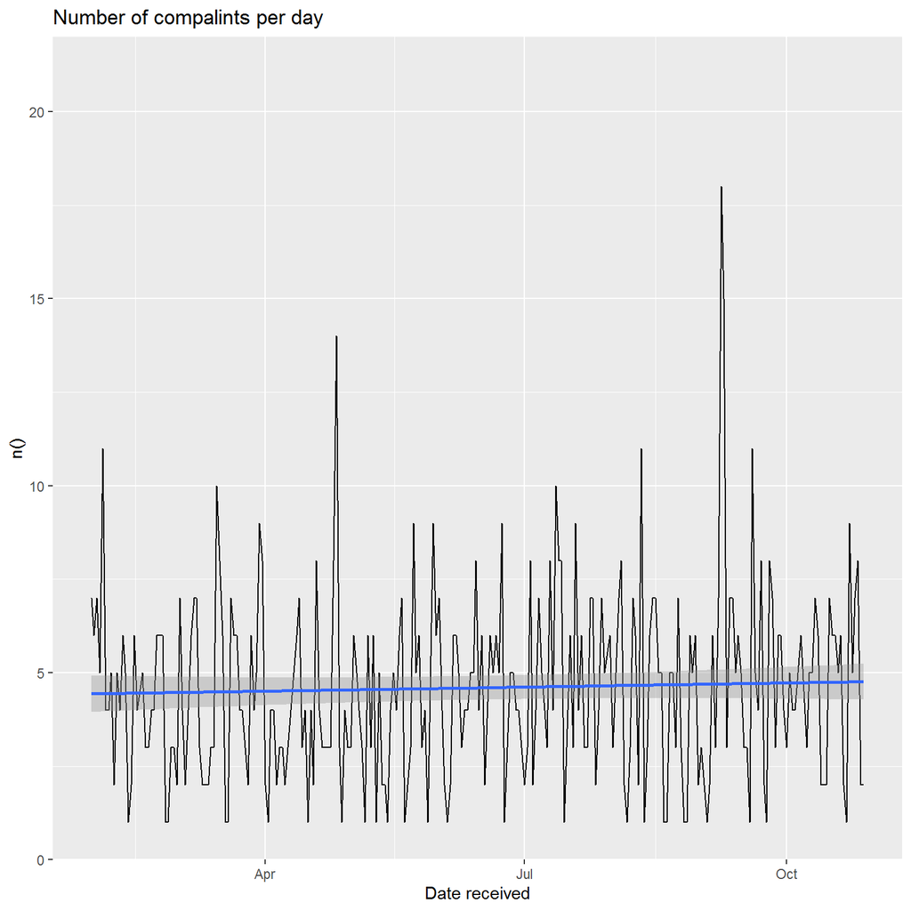

```r
p1 + geom_line() +  stat_smooth() -> p2
        lim <- as.Date(c("2017-01-30","2017-10-28"))
        p2 + scale_x_date(limits = lim)
```

### Textual Analysis

The narrative column show the original message from the customer.

To run python 1. install python 2. put python in global variables 3. open terminal (next to console) 4. run virtualenv python this will take a while 5. run .

On the first run of code chunk the console will ask do you want to install minconda

Still working on making this work

```python
#Loading dependencies
        import numpy as np
        import pandas as pd
        from collections import Counter
        import matplotlib.pyplot as plot
```

```python
#The 10,000 random sample
        Complaints = pd.read_csv('sample.csv')

        print(Complaints.head())
```

[output not shown]

```python
Complaints_mon = Complaints[Complaints['Company response to consumer'] == 'Closed with monetary relief']
        words = []

        for i in range(len(Complaints_mon.index)):
            words += Complaints_mon.iloc[i,3].split()

        word_c = pd.DataFrame()

        articles = ['or', 'an', 'your', 'a', 'with', 'by','and','my','on','/','the']
        word_c['Words'] = Counter(words).keys()
        word_c['Counts'] = Counter(words).values()
        word_c = word_c.sort_values('Counts', ascending = False)
        for i in articles:
            word_c = word_c[word_c.Words != i]

        word_c
```

[output not shown]